# week_09_review_cluster

## CMPINF 2100 Week 09

### Review KMeans and Introduce HCLUST

## Import Modules

```python
import pandas as pd
import numpy as np
import matplotlib.pyplot as plt

import seaborn as sns
```

Import functions from `sklearn` to support KMeans.

```python
from sklearn.preprocessing import StandardScaler
```

```python
from sklearn.decomposition import PCA
```

```python
from sklearn.cluster import KMeans
```

## Read data

```python
wine_url = 'http://archive.ics.uci.edu/ml/machine-learning-databases/wine/wine.data'
```

```python
wine_names = ['Cultivar', 'Alcohol', 'Malic_acid', 'Ash', 'Alcalinity_of_ash', 'Magnesium', 'Total_phenols',
              'Flavanoids', 'Nonflavanoid_phenols', 'Proanthocyanin', 'Color_intensity', 'Hue', 'OD280_OD315', 'Proline']
```

```python
wine_data = pd.read_csv(wine_url, names=wine_names)
```

```python
wine_data
```

|  | Cultivar | Alcohol | Malic_acid | Ash | Alcalinity_of_ash | Magnesium | Total_phenols | Flavanoids | Nonflavanoid_phenols | Proanthocyanin | Color_intensity | Hue | OD280_OD315 | Proline |
| --- | --- | --- | --- | --- | --- | --- | --- | --- | --- | --- | --- | --- | --- | --- |
| 0 | 1 | 14.23 | 1.71 | 2.43 | 15.6 | 127 | 2.80 | 3.06 | 0.28 | 2.29 | 5.64 | 1.04 | 3.92 | 1065 |
| 1 | 1 | 13.20 | 1.78 | 2.14 | 11.2 | 100 | 2.65 | 2.76 | 0.26 | 1.28 | 4.38 | 1.05 | 3.40 | 1050 |
| 2 | 1 | 13.16 | 2.36 | 2.67 | 18.6 | 101 | 2.80 | 3.24 | 0.30 | 2.81 | 5.68 | 1.03 | 3.17 | 1185 |
| 3 | 1 | 14.37 | 1.95 | 2.50 | 16.8 | 113 | 3.85 | 3.49 | 0.24 | 2.18 | 7.80 | 0.86 | 3.45 | 1480 |
| 4 | 1 | 13.24 | 2.59 | 2.87 | 21.0 | 118 | 2.80 | 2.69 | 0.39 | 1.82 | 4.32 | 1.04 | 2.93 | 735 |
| ... | ... | ... | ... | ... | ... | ... | ... | ... | ... | ... | ... | ... | ... | ... |
| 173 | 3 | 13.71 | 5.65 | 2.45 | 20.5 | 95 | 1.68 | 0.61 | 0.52 | 1.06 | 7.70 | 0.64 | 1.74 | 740 |
| 174 | 3 | 13.40 | 3.91 | 2.48 | 23.0 | 102 | 1.80 | 0.75 | 0.43 | 1.41 | 7.30 | 0.70 | 1.56 | 750 |
| 175 | 3 | 13.27 | 4.28 | 2.26 | 20.0 | 120 | 1.59 | 0.69 | 0.43 | 1.35 | 10.20 | 0.59 | 1.56 | 835 |
| 176 | 3 | 13.17 | 2.59 | 2.37 | 20.0 | 120 | 1.65 | 0.68 | 0.53 | 1.46 | 9.30 | 0.60 | 1.62 | 840 |
| 177 | 3 | 14.13 | 4.10 | 2.74 | 24.5 | 96 | 2.05 | 0.76 | 0.56 | 1.35 | 9.20 | 0.61 | 1.60 | 560 |

178 rows × 14 columns

```python
wine_data.info()
```

```
<class 'pandas.core.frame.DataFrame'>
RangeIndex: 178 entries, 0 to 177
Data columns (total 14 columns):
 #   Column                Non-Null Count  Dtype
---  ------                --------------  -----
 0   Cultivar              178 non-null    int64
 1   Alcohol               178 non-null    float64
 2   Malic_acid            178 non-null    float64
 3   Ash                   178 non-null    float64
 4   Alcalinity_of_ash     178 non-null    float64
 5   Magnesium             178 non-null    int64
 6   Total_phenols         178 non-null    float64
 7   Flavanoids            178 non-null    float64
 8   Nonflavanoid_phenols  178 non-null    float64
 9   Proanthocyanin        178 non-null    float64
 10  Color_intensity       178 non-null    float64
 11  Hue                   178 non-null    float64
 12  OD280_OD315           178 non-null    float64
 13  Proline               178 non-null    int64
dtypes: float64(11), int64(3)
memory usage: 19.6 KB
```

```python
wine_data.nunique()
```

```
Cultivar                  3
Alcohol                 126
Malic_acid              133
Ash                      79
Alcalinity_of_ash        63
Magnesium                53
Total_phenols            97
Flavanoids              132
Nonflavanoid_phenols     39
Proanthocyanin          101
Color_intensity         132
Hue                      78
OD280_OD315             122
Proline                 121
dtype: int64
```

```python
wine_data.Cultivar.value_counts()
```

```
Cultivar
2    71
1    59
3    48
Name: count, dtype: int64
```

```python
wine_data["Cultivar"] = wine_data.Cultivar.astype("category")
```

```python
wine_data.info()
```

```
<class 'pandas.core.frame.DataFrame'>
RangeIndex: 178 entries, 0 to 177
Data columns (total 14 columns):
 #   Column                Non-Null Count  Dtype
---  ------                --------------  -----
 0   Cultivar              178 non-null    category
 1   Alcohol               178 non-null    float64
 2   Malic_acid            178 non-null    float64
 3   Ash                   178 non-null    float64
 4   Alcalinity_of_ash     178 non-null    float64
 5   Magnesium             178 non-null    int64
 6   Total_phenols         178 non-null    float64
 7   Flavanoids            178 non-null    float64
 8   Nonflavanoid_phenols  178 non-null    float64
 9   Proanthocyanin        178 non-null    float64
 10  Color_intensity       178 non-null    float64
 11  Hue                   178 non-null    float64
 12  OD280_OD315           178 non-null    float64
 13  Proline               178 non-null    int64
dtypes: category(1), float64(11), int64(2)
memory usage: 18.5 KB
```

## Preprocessing

Before we can executre KMeans, we NEED to remove the MAGNITUDE and SCALE effects!!!

We need to STANDARDIZE the num cols BEFORE we can cluster!!

```python
wine_features = wine_data.select_dtypes("number").copy()
```

Lets now standardize the numeric columns!!!

```python
Xwine = StandardScaler().fit_transform(wine_features)
```

```python
Xwine.shape
```

```
(178, 13)
```

Execute PCA to support and streamline visualizations.

```python
pca_wine = PCA(n_components=2).fit_transform(Xwine)
```

```python
pca_wine.shape
```

```
(178, 2)
```

These are NEW vars that are created based on the original standardized features!!

```python
pca_wine_df = pd.DataFrame(pca_wine, columns=["pc01", "pc02"])
```

```python
pca_wine_df
```

|  | pc01 | pc02 |
| --- | --- | --- |
| 0 | 3.316751 | -1.443463 |
| 1 | 2.209465 | 0.333393 |
| 2 | 2.516740 | -1.031151 |
| 3 | 3.757066 | -2.756372 |
| 4 | 1.008908 | -0.869831 |
| ... | ... | ... |
| 173 | -3.370524 | -2.216289 |
| 174 | -2.601956 | -1.757229 |
| 175 | -2.677839 | -2.760899 |
| 176 | -2.387017 | -2.297347 |
| 177 | -3.208758 | -2.768920 |

178 rows × 2 columns

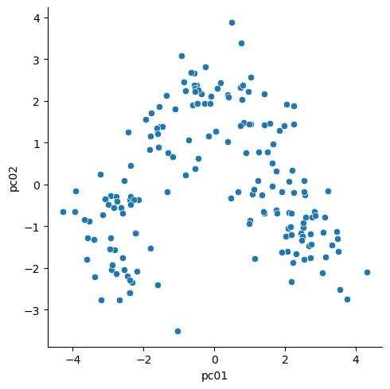

```python
sns.relplot(data=pca_wine_df, x="pc01", y="pc02")

plt.show()
```

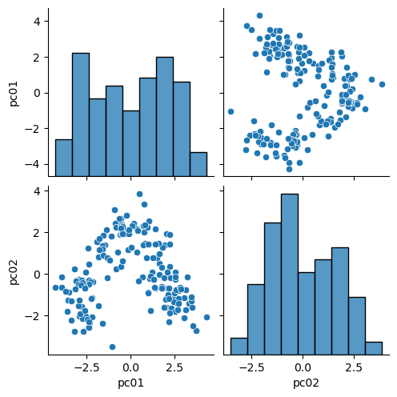

```python
sns.pairplot(data=pca_wine_df)

plt.show()
```

## KMeans

Last week we saw how to execute the Kmeans using 3 clusters.

This week, lets identify the OPTIMAL num of clusters using the KNEE BEND plot!!

We need to calculate the TOTAL WITHIN SUM OF SQUARES for many possible number of clusters!!

```python
tots_within = []

K = range(1, 31)

for k in K:
    km = KMeans(n_clusters=k, random_state=121, n_init=25, max_iter=500).fit(Xwine)
    tots_within.append(km.inertia_)
```

Visualize the TOTAL WITHIN SUM OF SQUARES vs the number of clusters!

Lets make the chart with matplotlib directly.

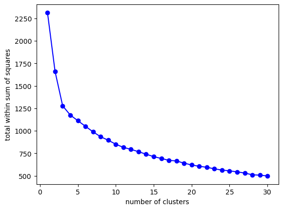

```python
fig, ax = plt.subplots()

ax.plot(K, tots_within, "bo-")
ax.set_xlabel("number of clusters")
ax.set_ylabel("total within sum of squares")

plt.show()
```

## Hierarchical Clustering

Hiearchical clutering still bases SIMILARITY on DISTANCES.

But, we **do not** need to specify the num of clusters upfront!

Instead, as the name states, clusters within clusters are formed!!

Hiearchical clustering will in effect try out ALL possible number of clusters for us!!!

And it provides a useful VISUALIZATION to interpret the clustering results!!

We will use sklearn quite often in this course, but for hiearchical clsutering, we will use functions from `SCIPY`.

Import the functions we need from SCIPY.

```python
from scipy.cluster import hierarchy
```

Hierarchical clustering still calculates distances. Therefore, it is critical to use STANDARDIZED variables just like KMeans!!!!

However, there is another kind of distance that needs to be calculated for hierarchical computing.

We will discuss that other kind of distance after examining some results.

This other kind of distance is referred to as the LINKAGE.

Linkages:

- **COMPLETE**: MAXIMUM distance between two clusters
- **SINGLE**: MINIMUM distance between two clusters
- **AVERAGE**: AVERAGE distance between two clusters
- **CENTROID**: Calculates the center of the clusters and then calculates the distance between two clusters

### COMPLETE LINKAGE

```python
hclust_complete = hierarchy.complete(Xwine)
```

```python
type(hclust_complete)
```

```
numpy.ndarray
```

Visualize the results witha specialized fig called a DENDROGRAM.

This presents the clustering results in a TREE LIKE structure.

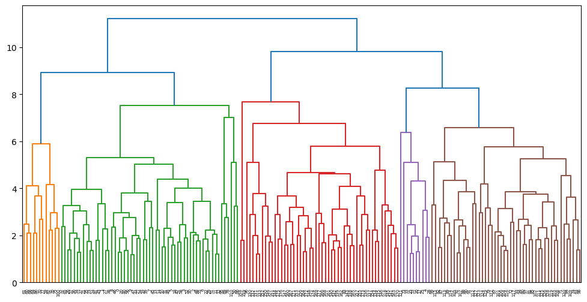

```python
fig = plt.figure(figsize=(12, 6))

dn = hierarchy.dendrogram(hclust_complete)

plt.show()
```

Bottom is called the NODES or LEAVES. The top lines are the ROOTS.

The leaves represent each observation or row.

The roots represents combining all rows into one cluster.

Agglomerative approach means that we start with each individual obs, cluster the ones close to it until everything is clustered. (Divisive is the opposite)

This is shown as the top line being one cluster!

Y-axis is a measure of dissimilarity.

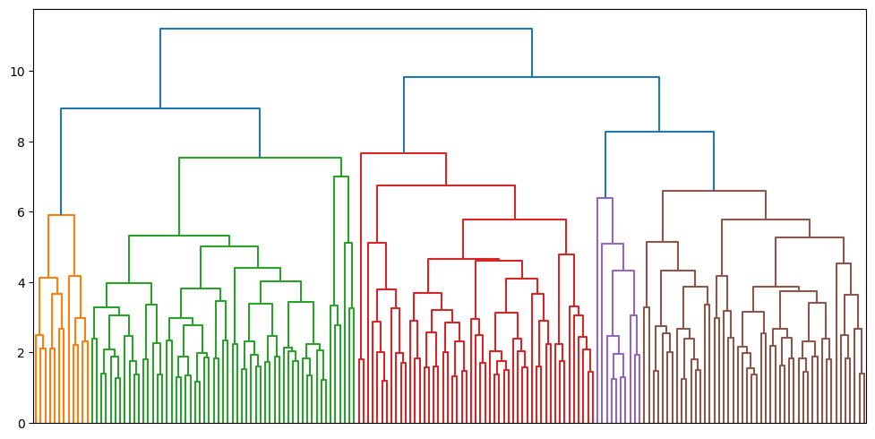

```python
fig = plt.figure(figsize=(12, 6))

dn = hierarchy.dendrogram(hclust_complete, no_labels=True)

plt.show()
```

### SINGLE LINKAGE

```python
hclust_single = hierarchy.single(Xwine)
```

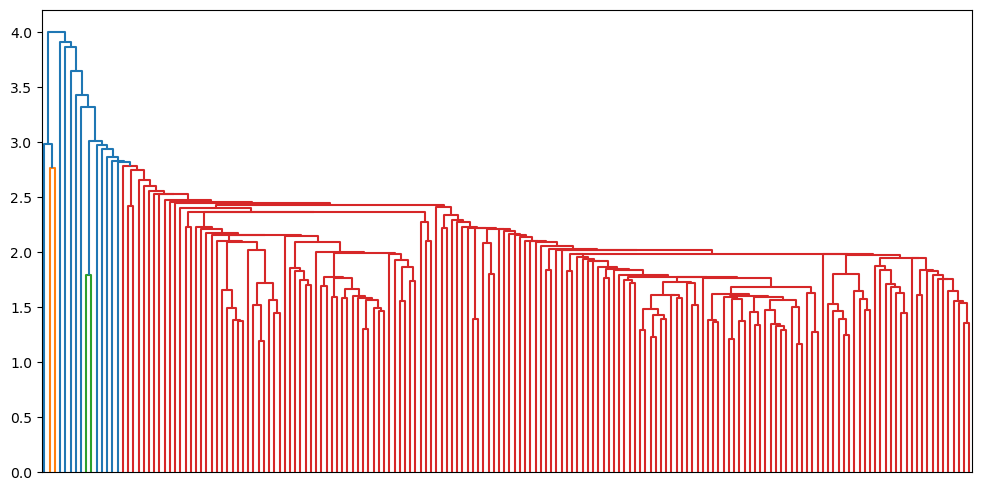

```python
plt.figure(figsize=(12,6))

dn = hierarchy.dendrogram(hclust_single, no_labels=True)

plt.show()
```

### AVERAGE LINKAGE

```python
hclust_average = hierarchy.average(Xwine)
```

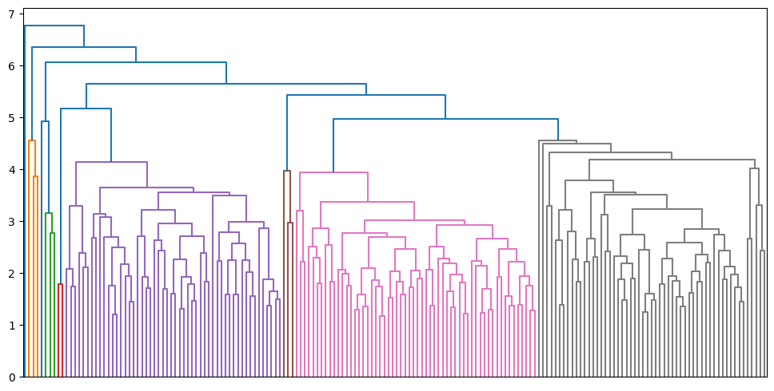

```python
plt.figure(figsize=(12,6))

dn = hierarchy.dendrogram(hclust_average, no_labels=True)

plt.show()
```

### CENTROID LINKAGE

```python
hclust_centroid = hierarchy.centroid(Xwine)
```

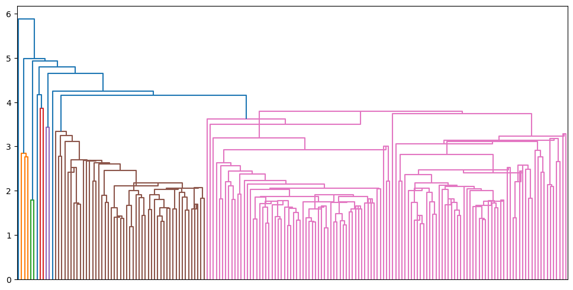

```python
plt.figure(figsize=(12,6))

dn = hierarchy.dendrogram(hclust_centroid, no_labels=True)

plt.show()
```

### Ward Method

```python
hclust_ward = hierarchy.ward(Xwine)
```

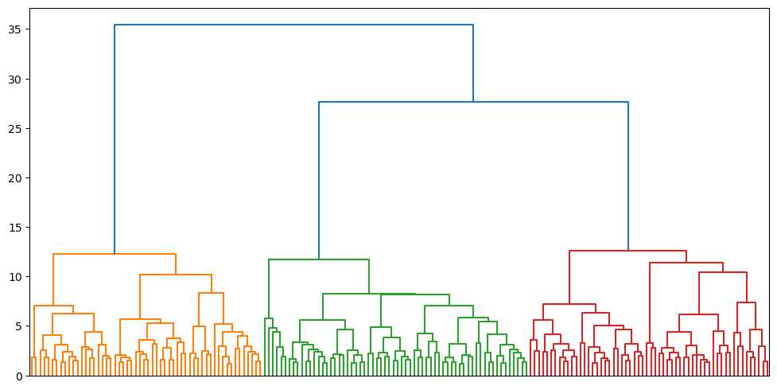

```python
plt.figure(figsize=(12,6))

dn = hierarchy.dendrogram(hclust_ward, no_labels=True)

plt.show()
```

### Cut the tree

One approach is to CUT based on HEIGHT.

```python
hierarchy.cut_tree(hclust_ward, height=25).shape
```

```
(178, 1)
```

```python
hierarchy.cut_tree(hclust_ward, height=25).ndim
```

```
2
```

```python
hierarchy.cut_tree(hclust_ward, height=25).ravel().shape
```

```
(178,)
```

```python
np.unique(hierarchy.cut_tree(hclust_ward, height=25).ravel())
```

```
array([0, 1, 2])
```

```python
np.unique(hierarchy.cut_tree(hclust_ward, height=20).ravel())
```

```
array([0, 1, 2])
```

```python
np.unique(hierarchy.cut_tree(hclust_ward, height=12).ravel())
```

```
array([0, 1, 2, 3, 4])
```

```python
np.unique(hierarchy.cut_tree(hclust_ward, height=10).ravel())
```

```
array([0, 1, 2, 3, 4, 5, 6, 7, 8])
```

A second approach is to specify the NUMBER of CLUSTERS you wish to return.

```python
hierarchy.cut_tree(hclust_ward, n_clusters=3).ravel()
```

```
array([0, 0, 0, 0, 0, 0, 0, 0, 0, 0, 0, 0, 0, 0, 0, 0, 0, 0, 0, 0, 0, 0,
       0, 0, 0, 0, 0, 0, 0, 0, 0, 0, 0, 0, 0, 0, 0, 0, 0, 0, 0, 0, 0, 0,
       0, 0, 0, 0, 0, 0, 0, 0, 0, 0, 0, 0, 0, 0, 0, 1, 2, 2, 1, 1, 1, 0,
       0, 1, 2, 1, 2, 0, 1, 0, 1, 1, 1, 2, 1, 1, 1, 1, 1, 2, 1, 1, 1, 1,
       1, 1, 1, 1, 1, 1, 1, 1, 2, 1, 1, 1, 1, 1, 1, 1, 1, 1, 1, 1, 1, 1,
       1, 1, 1, 1, 1, 1, 1, 1, 2, 1, 1, 0, 1, 1, 1, 1, 1, 1, 1, 1, 2, 2,
       2, 2, 2, 2, 2, 2, 2, 2, 2, 2, 2, 2, 2, 2, 2, 2, 2, 2, 2, 2, 2, 2,
       2, 2, 2, 2, 2, 2, 2, 2, 2, 2, 2, 2, 2, 2, 2, 2, 2, 2, 2, 2, 2, 2,
       2, 2])
```

```python
np.unique(hierarchy.cut_tree(hclust_ward, n_clusters=3).ravel())
```

```
array([0, 1, 2])
```

## Use the cluster results

We can do the same actions on the hierarchical clustering results that we did with KMeans!

```python
pca_wine_df["hclust_3"] = pd.Series(hierarchy.cut_tree(hclust_ward, n_clusters=3).ravel(), index=pca_wine_df.index).astype("category")
```

```python
pca_wine_df.info()
```

```
<class 'pandas.core.frame.DataFrame'>
RangeIndex: 178 entries, 0 to 177
Data columns (total 3 columns):
 #   Column    Non-Null Count  Dtype
---  ------    --------------  -----
 0   pc01      178 non-null    float64
 1   pc02      178 non-null    float64
 2   hclust_3  178 non-null    category
dtypes: category(1), float64(2)
memory usage: 3.2 KB
```

```python
pca_wine_df.hclust_3.value_counts()
```

```
hclust_3
0    64
1    58
2    56
Name: count, dtype: int64
```

Lets color the PCA scatter plot between PC01 and PC02 by the identified cluster groups!

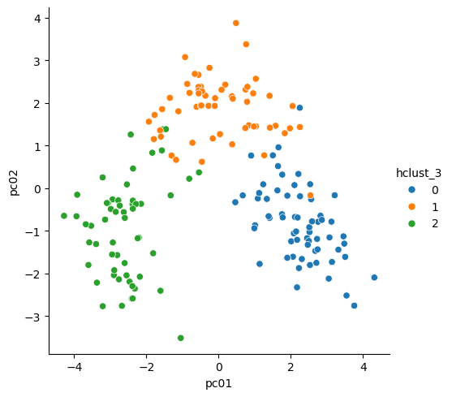

```python
sns.relplot(data=pca_wine_df, x="pc01", y="pc02", hue="hclust_3")

plt.show()
```

You should always compare the identified clusters to the known categories.

```python
pca_wine_df["Cultivar"] = wine_data.Cultivar
```

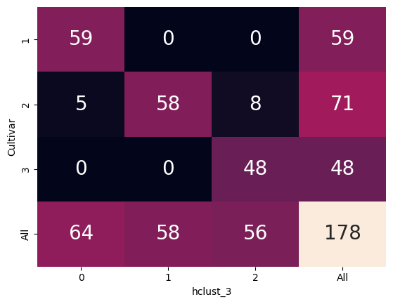

```python
fig, ax = plt.subplots()

sns.heatmap(data = pd.crosstab(pca_wine_df.Cultivar, pca_wine_df.hclust_3, margins=True),
            annot=True,
            annot_kws={"fontsize":20},
            cbar=False,
            fmt="g",
            ax=ax)
plt.show()
```

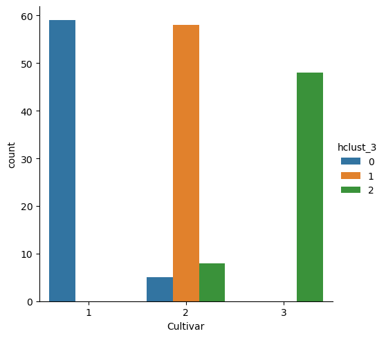

```python
sns.catplot(data=pca_wine_df, x="Cultivar", hue="hclust_3", kind="count")

plt.show()
```

### Explore the original features

Lets examine the CONDITIONAL DISTRIBUTIONS of the original wine numeric cols GIVEN the clusters!

```python
wine_copy = wine_data.copy()
```

```python
wine_copy["hclust_3"] = pca_wine_df.hclust_3
```

```python
wine_copy.info()
```

```
<class 'pandas.core.frame.DataFrame'>
RangeIndex: 178 entries, 0 to 177
Data columns (total 15 columns):
 #   Column                Non-Null Count  Dtype
---  ------                --------------  -----
 0   Cultivar              178 non-null    category
 1   Alcohol               178 non-null    float64
 2   Malic_acid            178 non-null    float64
 3   Ash                   178 non-null    float64
 4   Alcalinity_of_ash     178 non-null    float64
 5   Magnesium             178 non-null    int64
 6   Total_phenols         178 non-null    float64
 7   Flavanoids            178 non-null    float64
 8   Nonflavanoid_phenols  178 non-null    float64
 9   Proanthocyanin        178 non-null    float64
 10  Color_intensity       178 non-null    float64
 11  Hue                   178 non-null    float64
 12  OD280_OD315           178 non-null    float64
 13  Proline               178 non-null    int64
 14  hclust_3              178 non-null    category
dtypes: category(2), float64(11), int64(2)
memory usage: 18.8 KB
```

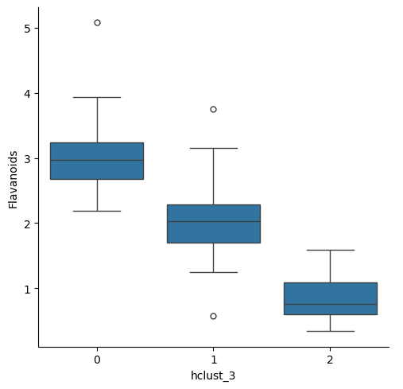

```python
sns.catplot(data=wine_copy, x="hclust_3", y="Flavanoids", kind="box")

plt.show()
```

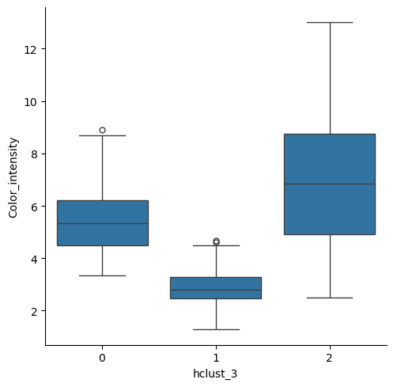

```python
sns.catplot(data=wine_copy, x="hclust_3", y="Color_intensity", kind="box")

plt.show()
```

Reshaped the WIDE FORMAT to the LONG FORMAT to enable exploring ALL of the original variables GROUPED by the clusters!!!

```python
lf = wine_copy.reset_index().\
rename(columns={"index":"rowid"}).\
melt(id_vars=["rowid", "Cultivar", "hclust_3"],
     value_vars=wine_copy.select_dtypes("number").columns)
```

```python
lf
```

|  | rowid | Cultivar | hclust_3 | variable | value |
| --- | --- | --- | --- | --- | --- |
| 0 | 0 | 1 | 0 | Alcohol | 14.23 |
| 1 | 1 | 1 | 0 | Alcohol | 13.20 |
| 2 | 2 | 1 | 0 | Alcohol | 13.16 |
| 3 | 3 | 1 | 0 | Alcohol | 14.37 |
| 4 | 4 | 1 | 0 | Alcohol | 13.24 |
| ... | ... | ... | ... | ... | ... |
| 2309 | 173 | 3 | 2 | Proline | 740.00 |
| 2310 | 174 | 3 | 2 | Proline | 750.00 |
| 2311 | 175 | 3 | 2 | Proline | 835.00 |
| 2312 | 176 | 3 | 2 | Proline | 840.00 |
| 2313 | 177 | 3 | 2 | Proline | 560.00 |

2314 rows × 5 columns

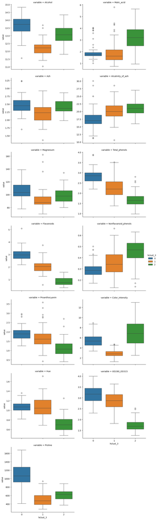

```python
sns.catplot(data=lf, x="hclust_3", y="value", col="variable", hue="hclust_3", col_wrap=2, kind="box", sharey=False)

plt.show()
```